# WorldHappinessAnaysis

Yi Heng Joshua Wu

5/6/2021

In Economics, there is a theory called “Easterlin Paradox”. Where the country’s GDP growth doesn’t improve happiness in the long-run.

To test this theory, my goal was to use the same data the World Happiness Report uses from 2015 - 2019, originated from GallUp Polls, to generate a model to find significant factors contributing to a country’s happiness index.

## Loading libraries

```r
library(dplyr)
library(corrplot)
library(ggplot2)
library(ggpubr)
library(aod)
library(MASS)
library(stargazer)
```

## Loading World Happiness Data from 2015 - 2019

```r
whr.raw.2015 = read.csv("2015.csv")
whr.raw.2016 = read.csv("2016.csv")
whr.raw.2017 = read.csv("2017.csv")
whr.raw.2018 = read.csv("2018.csv")
whr.raw.2019 = read.csv("2019.csv")
```

First check if the dimensions of the data sets match

```r
# Checking Dimensions
paste("WHR 2015 Data has", dim(whr.raw.2015)[1], "rows and", dim(whr.raw.2015)[2], "columns", sep=" ")
```

```
[1] "WHR 2015 Data has 158 rows and 12 columns"
```

```r
paste("WHR 2016 Data has", dim(whr.raw.2016)[1], "rows and", dim(whr.raw.2016)[2], "columns", sep=" ")
```

```
[1] "WHR 2016 Data has 157 rows and 13 columns"
```

```r
paste("WHR 2017 Data has", dim(whr.raw.2017)[1], "rows and", dim(whr.raw.2017)[2], "columns", sep=" ")
```

```
[1] "WHR 2017 Data has 155 rows and 12 columns"
```

```r
paste("WHR 2018 Data has", dim(whr.raw.2018)[1], "rows and", dim(whr.raw.2018)[2], "columns", sep=" ")
```

```
[1] "WHR 2018 Data has 156 rows and 9 columns"
```

```r
paste("WHR 2019 Data has", dim(whr.raw.2019)[1], "rows and", dim(whr.raw.2019)[2], "columns", sep=" ")
```

```
[1] "WHR 2019 Data has 156 rows and 9 columns"
```

Lets check for potential missing values in the data set as well.

```r
# Checking Missing Values
sapply(whr.raw.2015, function(x) sum(is.na(x)))
```

```
                      Country                        Region                Happiness.Rank
                            0                             0                             0
              Happiness.Score                Standard.Error      Economy..GDP.per.Capita.
                            0                             0                             0
                       Family      Health..Life.Expectancy.                       Freedom
                            0                             0                             0
Trust..Government.Corruption.                    Generosity             Dystopia.Residual
                            0                             0                             0
```

```r
sapply(whr.raw.2016, function(x) sum(is.na(x)))
```

```
                      Country                        Region                Happiness.Rank
                            0                             0                             0
              Happiness.Score     Lower.Confidence.Interval     Upper.Confidence.Interval
                            0                             0                             0
     Economy..GDP.per.Capita.                        Family      Health..Life.Expectancy.
                            0                             0                             0
                      Freedom Trust..Government.Corruption.                    Generosity
                            0                             0                             0
            Dystopia.Residual
                            0
```

```r
sapply(whr.raw.2017, function(x) sum(is.na(x)))
```

```
                      Country                Happiness.Rank               Happiness.Score
                            0                             0                             0
                 Whisker.high                   Whisker.low      Economy..GDP.per.Capita.
                            0                             0                             0
                       Family      Health..Life.Expectancy.                       Freedom
                            0                             0                             0
                   Generosity Trust..Government.Corruption.             Dystopia.Residual
                            0                             0                             0
```

```r
sapply(whr.raw.2018, function(x) sum(is.na(x)))
```

```
                Overall.rank            Country.or.region                        Score
                           0                            0                            0
              GDP.per.capita               Social.support      Healthy.life.expectancy
                           0                            0                            0
Freedom.to.make.life.choices                   Generosity    Perceptions.of.corruption
                           0                            0                            0
```

```r
sapply(whr.raw.2019, function(x) sum(is.na(x)))
```

```
                Overall.rank            Country.or.region                        Score
                           0                            0                            0
              GDP.per.capita               Social.support      Healthy.life.expectancy
                           0                            0                            0
Freedom.to.make.life.choices                   Generosity    Perceptions.of.corruption
                           0                            0                            0
```

It seems like there aren’t any missing values across all 5 data sets

## Data Cleaning

First drop the columns that are only present in some iterations of whr

```r
# Dropping columns that are not present across all data sets
whr.raw.2015 = subset(whr.raw.2015, select = -c(Dystopia.Residual, Standard.Error))
whr.raw.2016 = subset(whr.raw.2016, select = -c(Lower.Confidence.Interval,
                                                Upper.Confidence.Interval,
                                                Dystopia.Residual))
whr.raw.2017 = subset(whr.raw.2017, select = -c(Whisker.high,
                                                Whisker.low,
                                                Dystopia.Residual))
```

Standardizing the columns across all 5 data set

```r
# Standardized column names to "Country", "Region", "Happiness.Rank", "Happiness.Score", "GDP.per.Capita", "Freedom", "Trust..Government.Corruption", "Generosity", "Health..Life.Expectancy.", "Social Support"

# 2015 Data - Family is rename social support in later data sets
whr.raw.2015 = whr.raw.2015 %>%
  rename(
    GDP.per.Capita = Economy..GDP.per.Capita.,
    Social.support = Family
  )

# 2016 Data
whr.raw.2016 = whr.raw.2016 %>%
  rename(
    GDP.per.Capita = Economy..GDP.per.Capita.,
    Social.support = Family
  )

# 2017 Data
whr.raw.2017 = whr.raw.2017 %>%
  rename(
    GDP.per.Capita = Economy..GDP.per.Capita.,
    Social.support = Family
  )

# 2018 Data
whr.raw.2018 = whr.raw.2018 %>%
  rename(
    Trust..Government.Corruption. = Perceptions.of.corruption,
    Happiness.Rank = Overall.rank,
    Happiness.Score = Score,
    Country = Country.or.region,
    Freedom = Freedom.to.make.life.choices,
    Health..Life.Expectancy. = Healthy.life.expectancy,
    GDP.per.Capita = GDP.per.capita
  )

# 2019 Data
whr.raw.2019 = whr.raw.2019 %>%
  rename(
    Trust..Government.Corruption. = Perceptions.of.corruption,
    Happiness.Rank = Overall.rank,
    Happiness.Score = Score,
    Country = Country.or.region,
    Freedom = Freedom.to.make.life.choices,
    Health..Life.Expectancy. = Healthy.life.expectancy,
    GDP.per.Capita = GDP.per.capita
  )
```

Add the Region column back to 2017 to 2019 data and add missing values

```r
# Join
regions = whr.raw.2015[,c("Country", "Region")]
whr.raw.2017 = merge(x=whr.raw.2017, y = regions, by = "Country", all.x=TRUE)
whr.raw.2018 = merge(x=whr.raw.2018, y = regions, by = "Country", all.x=TRUE)
whr.raw.2019 = merge(x=whr.raw.2019, y = regions, by = "Country", all.x=TRUE)

# Manually fillling up Region Values - 2017
whr.raw.2017[14, "Region"] = 'Latin America and Caribbean'
whr.raw.2017[56, "Region"] = 'Eastern Asia'
whr.raw.2017[97, "Region"]= 'Sub-Saharan Africa'
whr.raw.2017[125, "Region"]= 'Sub-Saharan Africa'
whr.raw.2017[128, "Region"]= 'Sub-Saharan Africa'
whr.raw.2017[135, "Region"] = 'Eastern Asia'

# Manually filling in data - 2018
whr.raw.2018[14, "Region"] = 'Latin America and Caribbean'
whr.raw.2018[98, "Region"] = 'Sub-Saharan Africa'
whr.raw.2018[105, "Region"]= "Western Europe"
whr.raw.2018[126, "Region"]= 'Sub-Saharan Africa'
whr.raw.2018[129, "Region"]= 'Sub-Saharan Africa'
whr.raw.2018[141, "Region"] = "Latin America and Caribbean"

# Manually filling in data - 2019
whr.raw.2019[47, "Region"] = 'Sub-Saharan Africa'
whr.raw.2019[97, "Region"] = 'Sub-Saharan Africa'
whr.raw.2019[104, "Region"]= "Western Europe"
whr.raw.2019[105, "Region"]= "Western Europe"
whr.raw.2019[126, "Region"]= 'Sub-Saharan Africa'
whr.raw.2019[129, "Region"]= 'Sub-Saharan Africa'
whr.raw.2019[141, "Region"] = "Latin America and Caribbean"


# Impute trust score based on average of UAE Trust score in other years
whr.raw.2018[147, "Trust..Government.Corruption."] = "0.31"
```

Concatenate the data frames

```r
whr.raw.2015["Year"] = 2015
whr.raw.2016["Year"] = 2016
whr.raw.2017["Year"] = 2017
whr.raw.2018["Year"] = 2018
whr.raw.2019["Year"] = 2019

whr.all = rbind(whr.raw.2015, whr.raw.2016, whr.raw.2017, whr.raw.2018, whr.raw.2019)
whr.all$Trust..Government.Corruption. = as.numeric(whr.all$Trust..Government.Corruption.)
head(whr.all)
```

|  | Country | Region | Happiness.Rank | Happiness.Score | GDP.per.Capita | Social.support | Health..Life.Expectancy. | Freedom | Trust..Government.Corruption. | Generosity | Year |
| --- | --- | --- | --- | --- | --- | --- | --- | --- | --- | --- | --- |
| 1 | Switzerland | Western Europe | 1 | 7.587 | 1.39651 | 1.34951 | 0.94143 | 0.66557 | 0.41978 | 0.29678 | 2015 |
| 2 | Iceland | Western Europe | 2 | 7.561 | 1.30232 | 1.40223 | 0.94784 | 0.62877 | 0.14145 | 0.43630 | 2015 |
| 3 | Denmark | Western Europe | 3 | 7.527 | 1.32548 | 1.36058 | 0.87464 | 0.64938 | 0.48357 | 0.34139 | 2015 |
| 4 | Norway | Western Europe | 4 | 7.522 | 1.45900 | 1.33095 | 0.88521 | 0.66973 | 0.36503 | 0.34699 | 2015 |
| 5 | Canada | North America | 5 | 7.427 | 1.32629 | 1.32261 | 0.90563 | 0.63297 | 0.32957 | 0.45811 | 2015 |
| 6 | Finland | Western Europe | 6 | 7.406 | 1.29025 | 1.31826 | 0.88911 | 0.64169 | 0.41372 | 0.23351 | 2015 |

After we are done with the combined dataset, we can work on some visualizations!

## Exploratory Data Analysis

### Spearman Rank Correlation

Since the rank is an ordinal variable, we need to use Spearman’s rank correlation the explore the crucial variables for our model. We will focus on 2015.

```r
cor.test(x=whr.raw.2015$GDP.per.Capita, y=whr.raw.2015$Happiness.Rank, method = 'spearman')
```

```
Cannot compute exact p-value with ties
```

```
    Spearman's rank correlation rho

data:  whr.raw.2015$GDP.per.Capita and whr.raw.2015$Happiness.Rank
S = 1180421, p-value < 2.2e-16
alternative hypothesis: true rho is not equal to 0
sample estimates:
       rho
-0.7957028
```

```r
cor.test(x=whr.raw.2015$Social.support, y=whr.raw.2015$Happiness.Rank, method = 'spearman')
```

```
Cannot compute exact p-value with ties
```

```
    Spearman's rank correlation rho

data:  whr.raw.2015$Social.support and whr.raw.2015$Happiness.Rank
S = 1163550, p-value < 2.2e-16
alternative hypothesis: true rho is not equal to 0
sample estimates:
      rho
-0.770038
```

```r
cor.test(x=whr.raw.2015$Health..Life.Expectancy., y=whr.raw.2015$Happiness.Rank, method = 'spearman')
```

```
Cannot compute exact p-value with ties
```

```
    Spearman's rank correlation rho

data:  whr.raw.2015$Health..Life.Expectancy. and whr.raw.2015$Happiness.Rank
S = 1154954, p-value < 2.2e-16
alternative hypothesis: true rho is not equal to 0
sample estimates:
       rho
-0.7569604
```

```r
cor.test(x=whr.raw.2015$Freedom, y=whr.raw.2015$Happiness.Rank, method = 'spearman')
```

```
Cannot compute exact p-value with ties
```

```
    Spearman's rank correlation rho

data:  whr.raw.2015$Freedom and whr.raw.2015$Happiness.Rank
S = 1036229, p-value = 2.301e-15
alternative hypothesis: true rho is not equal to 0
sample estimates:
       rho
-0.5763522
```

```r
cor.test(x=whr.raw.2015$Trust..Government.Corruption., y=whr.raw.2015$Happiness.Rank, method = 'spearman')
```

```
Cannot compute exact p-value with ties
```

```
    Spearman's rank correlation rho

data:  whr.raw.2015$Trust..Government.Corruption. and whr.raw.2015$Happiness.Rank
S = 856142, p-value = 0.0001126
alternative hypothesis: true rho is not equal to 0
sample estimates:
       rho
-0.3023969
```

```r
cor.test(x=whr.raw.2015$Generosity, y=whr.raw.2015$Happiness.Rank, method = 'spearman')
```

```
Cannot compute exact p-value with ties
```

```
    Spearman's rank correlation rho

data:  whr.raw.2015$Generosity and whr.raw.2015$Happiness.Rank
S = 770729, p-value = 0.03024
alternative hypothesis: true rho is not equal to 0
sample estimates:
      rho
-0.172463
```

It appears that the rank is negatively correlated with the variables in 2015. In other words, higher measures of coefficient lowers the country’s happiness rank.

### Pairplot

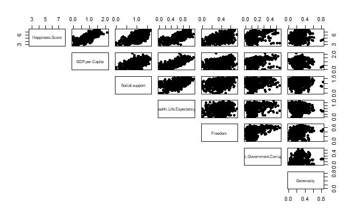

```r
whr.all.num = whr.all[, -c(1,2,3, 11)]
pairs(whr.all.num, pch=19, lower.panel=NULL)
```

The pairplot shows the general trend between each variables. Unfortunately, there seems to be significant overplotting due to the number of countries involved. We will have to used correlation plot instead.

### Correlation Plot

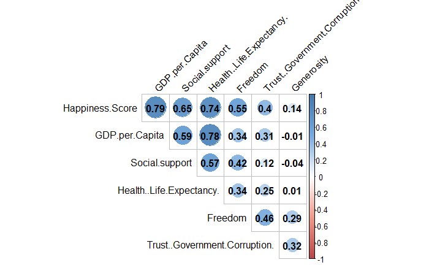

```r
col <- colorRampPalette(c("#BB4444", "#EE9988", "#FFFFFF", "#77AADD", "#4477AA"))
corrplot(cor(whr.all.num), col=col(200),  type="upper",
         addCoef.col = "black", tl.col="black", tl.srt=45, diag=FALSE )
```

The correlation plot shows the correlation between each variable with 1 illustrating strong positive correlation and -1 being strong negative correlation.

It is interesting that the rank version and the average version shows comptely opposite stories.

### Top 10 Countries for all average variables

Lets take the average of the measures across the years and see which country is the best in each category.

```r
top10 = whr.all %>%
  group_by(Country) %>%
  summarise(avg_happy = mean(Happiness.Score), avg_gdp = mean(GDP.per.Capita),
            avg_social = mean(Social.support), avg_life = mean(Health..Life.Expectancy.),
            avg_free = mean(Freedom), avg_trust = mean(Trust..Government.Corruption.))
```

```r
top10happy = ggplot(data.frame(top10[order(top10$avg_happy, decreasing = TRUE),][c(1:10),]),aes(x=reorder(as.factor(Country), -avg_happy), y=avg_happy)) + geom_point() +
  theme(axis.text.x = element_text(angle=45)) +
    xlab("Country") +
  ylab("Happiness") +
  ggtitle("Top 10 Countries with highest average Happiness")
```

```r
top10gdp = ggplot(data.frame(top10[order(top10$avg_happy, decreasing = TRUE),][c(1:10),]),aes(x=reorder(as.factor(Country), -avg_gdp), y=avg_gdp)) + geom_point() +
  theme(axis.text.x = element_text(angle=45)) +
    xlab("Country") +
  ylab("GDP Per Capita") +
  ggtitle("Top 10 Countries with highest average GDP per Capita Countries")
```

```r
top10life = ggplot(data.frame(top10[order(top10$avg_happy, decreasing = TRUE),][c(1:10),]),aes(x=reorder(as.factor(Country), -avg_life), y=avg_life)) + geom_point() +
  theme(axis.text.x = element_text(angle=45)) +
  xlab("Country") +
  ylab("Health Life Expectancy") +
  ggtitle("Top 10 Countries with highest average Health Life Expectancy")
```

```r
top10free = ggplot(data.frame(top10[order(top10$avg_happy, decreasing = TRUE),][c(1:10),]),aes(x=reorder(as.factor(Country), -avg_free), y=avg_free)) + geom_point() +
  theme(axis.text.x = element_text(angle=45)) +
  xlab("Country") +
  ylab("Freedom") +
  ggtitle("Top 10 Countries with highest average Freedom")
```

```r
top10trust = ggplot(data.frame(top10[order(top10$avg_happy, decreasing = TRUE),][c(1:10),]),aes(x=reorder(as.factor(Country), -avg_trust), y=avg_trust)) + geom_point() +
  theme(axis.text.x = element_text(angle=45)) +
    xlab("Country") +
  ylab("Trust for Government") +
  ggtitle("Top 10 Countries with highest with highest average trust for government")
```

```r
top10social = ggplot(data.frame(top10[order(top10$avg_happy, decreasing = TRUE),][c(1:10),]),aes(x=reorder(as.factor(Country), -avg_social), y=avg_social)) + geom_point() +
  theme(axis.text.x = element_text(angle=45)) +
    xlab("Country") +
  ylab("Social Support") +
  ggtitle("Top 10 Countries with highest average Social Support")
```

```
$`1`

$`2`

$`3`

attr(,"class")
[1] "list"      "ggarrange"
```

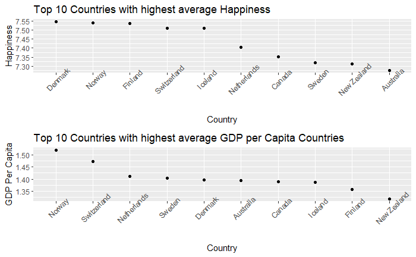

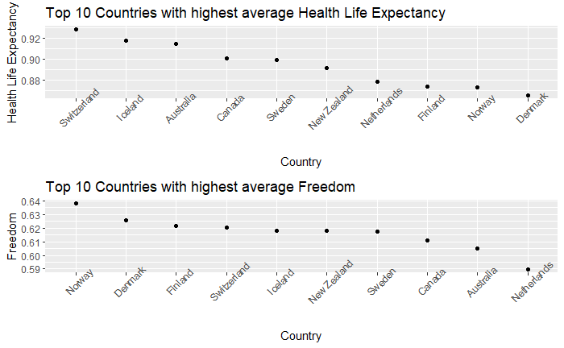

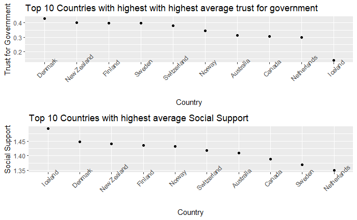

```r
ggarrange(top10happy, top10gdp, top10life,
          top10free, top10trust, top10social,
          ncol = 1, nrow = 2)
```

### Happiness by Region

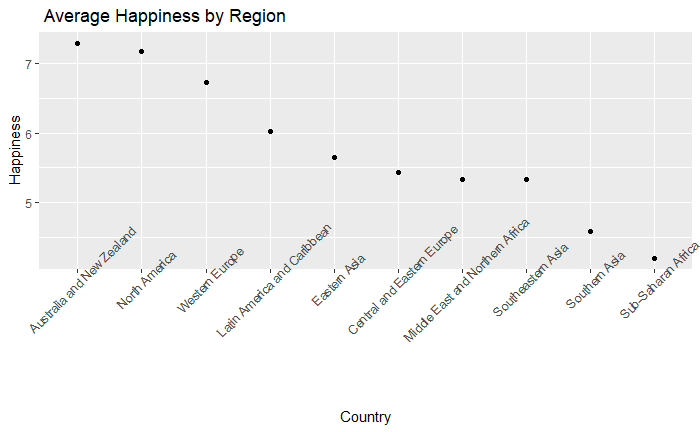

```r
regionhappy = whr.all %>%
  group_by(Region) %>%
  summarise(avg_happy = mean(Happiness.Score))

ggplot(regionhappy, aes(x=reorder(as.factor(Region), -avg_happy), y=avg_happy)) + geom_point() +
  theme(axis.text.x = element_text(angle=45)) +
    xlab("Country") +
  ylab("Happiness") +
  ggtitle(" Average Happiness by Region")
```

Obviously Australia and New Zealand have the highest happiness given only two countries were involved, pulling the average up. North America and Western Europe closely follow, while Sub-Saharan Africa has the lowest average by region. There seemed to be preliminary evidence against the Easterlin paradox.

## Modeling

To start off we will consider an ordinal logistic regression based on the rank. The choice of the model is due to the happiness score being a linear combination of the other measures - an automatic positive correlation. To mitigate this biased, I will regress the happiness country each year to the other numeric variables. I will also run a linear regression on the average score on the other average measures

```r
whr.raw.2018$Trust..Government.Corruption. = as.numeric(whr.raw.2018$Trust..Government.Corruption.)

olr.2015 = polr(as.factor(Happiness.Rank) ~ GDP.per.Capita + Social.support + Health..Life.Expectancy. + Freedom + Trust..Government.Corruption. + Generosity, data = whr.raw.2015, Hess=TRUE)

olr.2016 = polr(as.factor(Happiness.Rank) ~ GDP.per.Capita + Social.support + Health..Life.Expectancy. + Freedom + Trust..Government.Corruption. + Generosity, data = whr.raw.2016, Hess=TRUE)

olr.2017 = polr(as.factor(Happiness.Rank) ~ GDP.per.Capita + Social.support + Health..Life.Expectancy. + Freedom + Trust..Government.Corruption. + Generosity, data = whr.raw.2017, Hess=TRUE)

olr.2018 = polr(as.factor(Happiness.Rank) ~ GDP.per.Capita + Social.support + Health..Life.Expectancy. + Freedom + Trust..Government.Corruption. + Generosity, data = whr.raw.2018, Hess=TRUE)

olr.2019 = polr(as.factor(Happiness.Rank) ~ GDP.per.Capita + Social.support + Health..Life.Expectancy. + Freedom + Trust..Government.Corruption. + Generosity, data = whr.raw.2015, Hess=TRUE)


stargazer(olr.2015, olr.2016, olr.2017, olr.2018, olr.2019, title="Happiness",
          align = TRUE, dep.var.labels = "Happiness.Rank", type = "html")
```

**Happiness**

|  | *Dependent variable:* |  |  |  |  |
| --- | --- | --- | --- | --- | --- |
|  | Happiness.Rank |  |  |  |  |
|  | (1) | (2) | (3) | (4) | (5) |
| GDP.per.Capita | -2.443*** | -2.598*** | -3.039*** | -3.615*** | -2.443*** |
|  | (0.723) | (0.734) | (0.747) | (0.792) | (0.723) |
| Social.support | -5.212*** | -4.572*** | -4.799*** | -3.919*** | -5.212*** |
|  | (0.851) | (0.829) | (0.777) | (0.732) | (0.851) |
| Health..Life.Expectancy. | -3.643*** | -4.811*** | -4.623*** | -2.729** | -3.643*** |
|  | (1.091) | (1.226) | (1.196) | (1.188) | (1.091) |
| Freedom | -4.111*** | -5.171*** | -5.920*** | -5.486*** | -4.111*** |
|  | (1.265) | (1.358) | (1.260) | (1.136) | (1.265) |
| Trust..Government.Corruption. | -3.006** | -2.840* | -1.861 | -3.134 | -3.006** |
|  | (1.484) | (1.693) | (1.955) | (2.174) | (1.484) |
| Generosity | -1.164 | -0.991 | -0.987 | -0.498 | -1.164 |
|  | (1.231) | (1.199) | (1.156) | (1.709) | (1.231) |
| Observations | 158 | 157 | 155 | 156 | 158 |
| *Note:* | p<0.1; p<0.05; p<0.01 |  |  |  |  |

```r
lm.happy = lm(Happiness.Score ~  GDP.per.Capita + Social.support + Health..Life.Expectancy. + Freedom + Trust..Government.Corruption. + Generosity, data = whr.all.num)
summary(lm.happy)
```

```
Call:
lm(formula = Happiness.Score ~ GDP.per.Capita + Social.support +
    Health..Life.Expectancy. + Freedom + Trust..Government.Corruption. +
    Generosity, data = whr.all.num)

Residuals:
     Min       1Q   Median       3Q      Max
-1.92978 -0.32560  0.01677  0.35611  1.66219

Coefficients:
                              Estimate Std. Error t value Pr(>|t|)
(Intercept)                    2.17669    0.07978  27.284  < 2e-16 ***
GDP.per.Capita                 1.14193    0.08296  13.764  < 2e-16 ***
Social.support                 0.64346    0.08068   7.975 5.45e-15 ***
Health..Life.Expectancy.       1.00742    0.13137   7.669 5.22e-14 ***
Freedom                        1.47811    0.16321   9.057  < 2e-16 ***
Trust..Government.Corruption.  0.86255    0.22310   3.866 0.000120 ***
Generosity                     0.59189    0.17561   3.371 0.000787 ***
---
Signif. codes:  0 ‘***’ 0.001 ‘**’ 0.01 ‘*’ 0.05 ‘.’ 0.1 ‘ ’ 1

Residual standard error: 0.5497 on 775 degrees of freedom
Multiple R-squared:  0.7641,    Adjusted R-squared:  0.7623
F-statistic: 418.5 on 6 and 775 DF,  p-value: < 2.2e-16
```

As seen from the average regression, GDP, Life Expectancy, and Freedom are indeed positively correlated with the average happiness score.

Overall, there is somewhat ambiguous evidence regarding the Easterlin paradox. However, it seems like GDP, Life Expectancy, and Freedom helps a country’s happiness on an aggregate level. For immigrants with a preference in happiness, the Nordic countries and Oceania is the optimal choice.

## Refernece

- Source of Data: https://www.kaggle.com/unsdsn/world-happiness
- Spearman Correlation: https://www.kaggle.com/unsdsn/world-happiness
- Ordinal Logistic Regression: https://stats.idre.ucla.edu/r/dae/ordinal-logistic-regression/